# HW3

### Problem 1

#### 1A)

The first algorithm makes 8 mistakes, with 3 birds labeled as people and 5 people labeled as birds. The second algorithm only mistakes 1 bird as a person, but labels 11 people as birds, so has a total of 12 mistakes. The first algorithm makes fewer mistakes, with an accuracy of 92% compared to 88% for the second algorithm.

#### 1B)

The second algorithm is better for the zoo because even though it makes more mistakes, it makes fewer mistakes when identifying birds. Falsely identifying a human as a bird is not as bad for the zoo, as it is only a minor inconvenience, so it is worth the trade off of having more humans identified as birds if it means less birds will be identified as humans.

#### 1C)

##### First algorithm

|  | True Bird | True Person |
| --- | --- | --- |
| NN Bird | 92 | 0 |
| NN Person | 7 | 1 |

##### Second algorithm

|  | True Bird | True Person |
| --- | --- | --- |
| NA Bird | 97 | 0 |
| NA Person | 2 | 1 |

### Problem 2

#### Example 1)

#### Example 2)

#### 2A)

Using the formula for convolving two distributions, we get the probability density of the sum of two exponentional functions as $f_z(z) = \int_0^z \lambda_1 e^{-\lambda_1 x} \lambda_2 e^{\lambda_2 (z-x)} dx =\lambda^2 ze^{-\lambda z}$ when $\lambda_1 = \lambda_2$

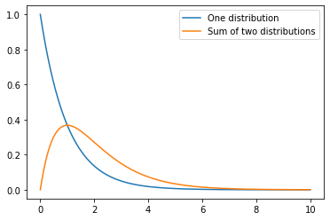

```python
import matplotlib.pyplot as plt
import numpy as np
x = np.linspace(0,10,1000)

# Distributions where lambda = 1
plt.plot(x, np.exp(-x), label='One distribution')
plt.plot(x, x*np.exp(-x), label='Sum of two distributions')
plt.legend()
```

#### 2B)

Looking for a distribution that is the ratio of two normal distributions, I found the ratio distribution, and the Cauchy distribution, which is the case of the ratio distribution that is normal distributions with a mean of 0. The Cauchy distribution is defined as $f(x,\gamma) = { 1 \over \pi \gamma } \left[ { \gamma^2 \over (x)^2 + \gamma^2 } \right]$ for a distribution with a mean of 0, where $\gamma$ is the scale factor.

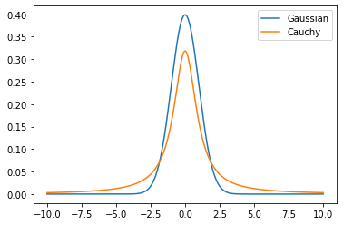

```python
from scipy.stats import norm
x = np.linspace(-10,10,1000)
def cauchy(x, gamma):
    return (1/np.pi)*(gamma**2 / (x**2 + gamma**2))

plt.plot(x, norm.pdf(x), label='Gaussian')
plt.plot(x, cauchy(x, 1), label='Cauchy')
plt.legend()
plt.show()
```

#### 2C)

For a 2D Gaussian, since the distribution is given by a vector the pdf is found with the square root of the sum of the squares. This is equivalent to a chi-squared distribution, which is also the square root of the sum of the squares of distributions.